# I-Vax Game Analysis

In this notebook we present the results of the implementation of the analysis we conducted on our proof-of-concept implementation of the interactive vaccination (I-Vax) game presented in our paper. We refer to the paper for the discussion and presentation of the results.

```r
# Remove annoying warnings
options(warn=-1)

# Import libraries
library("plyr")
library("dplyr")
library("imputeTS")
library("lme4")

# For log odds from models
library("broom.mixed")

# For plots
library("ggeffects")
library("ggplot2")
library("survminer")
library("cowplot")

# Survival
library("survival")
library("coxme")
```

# 1 Data Preparation

Let’s prepare the data for the models, starting with the round (waves) outcomes.

```r
# Read data
mydata14 <- read.table("Anonymized Data/end_of_wave_status_1-4.csv", header=TRUE, row.names='X', sep=",")
mydata14 <- mydata14[!duplicated(mydata14), ] # Remove duplicates if it's the case

mydata58 <- read.table("Anonymized Data/end_of_wave_status_5-8.csv", header=TRUE, row.names='X', sep=",")
mydata58 <- mydata58[!duplicated(mydata58), ] # Remove duplicates if it's the case

mydata912 <- read.table("Anonymized Data/end_of_wave_status_9-12.csv", header=TRUE, row.names='X', sep=",")
mydata912 <- mydata912[!duplicated(mydata912), ] # Remove duplicates if it's the case
```

Let’s encode the states:

- **I** **= 0** as well as **R** **= 0**, since they both represent the fact that the player got infected (even if recovered)
- **V = 1** and **A = 1**, these are the cases where the user was vaccinated or still awaiting the vaccination
- **S = 2**, susceptible players

```r
# Apply the function
mydata14['state'] <- lapply(mydata14['state'], function(x) mapvalues(x, c("I", "R", "V", "A", "S"), c(0, 0, 1, 1, 2)))
mydata58['state'] <- lapply(mydata58['state'], function(x) mapvalues(x, c("I", "R", "V", "A", "S"), c(0, 0, 1, 1, 2)))
mydata912['state'] <- lapply(mydata912['state'], function(x) mapvalues(x, c("I", "R", "V", "A", "S"), c(0, 0, 1, 1, 2)))
```

The next step is to transform the points to dummy points, to ease the fit of the models:

- **0** if there was no point loss
- **1** if there was point loss

```r
# Function to map values
dummy_points <- function(points, state){
  res <- 0
  if(state == 0){ #Infected
    if(points == 100)
      res <- 0
    else
      res <- 1
  } else if (state == 1){ #Vaccinated
    if(points == 90)
      res <- 0
    else
      res <- 1
  } else if (state == 2){ #Susceptible
    res <- 0
  }

  return(res)
}

# Apply it
mydata14['points'] <- apply(mydata14[,c('points', 'state')], 1, function(x) dummy_points(as.integer(x[1]), as.integer(x[2])))
mydata58['points'] <- apply(mydata58[,c('points', 'state')], 1, function(x) dummy_points(as.integer(x[1]), as.integer(x[2])))
mydata912['points'] <- apply(mydata912[,c('points', 'state')], 1, function(x) dummy_points(as.integer(x[1]), as.integer(x[2])))

print(mydata14)
```

|  | user | points | state | timestamp | vaccination_time | wave_no | decision |
| --- | --- | --- | --- | --- | --- | --- | --- |
| 0 | 390 | 0 | 1 | 2014-09-15 07:54:32 | 2014-09-10 23:05:00 | 1 | 1 |
| 1 | 392 | 0 | 1 | 2014-09-15 07:53:12 | 2014-09-08 14:15:00 | 1 | 1 |
| 2 | 148 | 1 | 0 | 2014-09-15 07:54:32 |  | 1 | 0 |
| 3 | 427 | 0 | 1 | 2014-09-15 07:52:53 | 2014-09-12 00:30:00 | 1 | 1 |
| 4 | 70 | 0 | 1 | 2014-09-15 07:52:54 | 2014-09-08 15:45:00 | 1 | 1 |
| 5 | 106 | 0 | 2 | 2014-09-15 07:54:32 |  | 1 | 0 |
| 6 | 166 | 1 | 0 | 2014-09-15 07:51:12 |  | 1 | 0 |
| 7 | 133 | 0 | 2 | 2014-09-15 07:54:36 |  | 1 | 0 |
| 8 | 184 | 1 | 0 | 2014-09-15 07:52:12 |  | 1 | 0 |
| 9 | 370 | 0 | 2 | 2014-09-15 07:51:20 |  | 1 | 0 |

[output cut: 990 more lines]

Next we have to combine the information from the subsequent waves to have the correct factors. We will also add a control variable which indicates which of the **feedback_setting** the round took place into (1 no feedback, 2 local feedback or 3 global feedback). Finally there will be two distinct dataframes, one which contains data from all the the rounds (that can therefore only be used without considering the feedback) and the other with data from the rounds which had feedback.

```r
# Split data in waves
wave1 <- mydata14[mydata14['wave_no'] == 1,]
wave2 <- mydata14[mydata14['wave_no'] == 2,]
wave3 <- mydata14[mydata14['wave_no'] == 3,]
wave4 <- mydata14[mydata14['wave_no'] == 4,]
wave5 <- mydata58[mydata58['wave_no'] == 5,]
wave6 <- mydata58[mydata58['wave_no'] == 6,]
wave7 <- mydata58[mydata58['wave_no'] == 7,]
wave8 <- mydata58[mydata58['wave_no'] == 8,]
wave9 <- mydata912[mydata912['wave_no'] == 9,]
wave10 <- mydata912[mydata912['wave_no'] == 10,]
wave11 <- mydata912[mydata912['wave_no'] == 11,]
wave12 <- mydata912[mydata912['wave_no'] == 12,]

# Add feedback_setting
wave1['feedback_setting'] <- 1
wave2['feedback_setting'] <- 1
wave3['feedback_setting'] <- 1
wave4['feedback_setting'] <- 1
wave5['feedback_setting'] <- 2
wave6['feedback_setting'] <- 2
wave7['feedback_setting'] <- 2
wave8['feedback_setting'] <- 2
wave9['feedback_setting'] <- 3
wave10['feedback_setting'] <- 3
wave11['feedback_setting'] <- 3
wave12['feedback_setting'] <- 3

# Aggregate data for waves
train12 <- merge(wave1[c("user", "points", "state", "decision")], wave2[c("user", "wave_no", "decision", "feedback_setting")],
                 by="user", suffixes=c("_prev", ""))
train23 <- merge(wave2[c("user", "points", "state", "decision")], wave3[c("user", "wave_no", "decision", "feedback_setting")],
                 by="user", suffixes=c("_prev", ""))
train34 <- merge(wave3[c("user", "points", "state", "decision")], wave4[c("user", "wave_no", "decision", "feedback_setting")],
                 by="user", suffixes=c("_prev", ""))

train45 <- merge(wave4[c("user", "points", "state", "decision")], wave5[c("user", "wave_no", "decision", "feedback_setting")],
                 by="user", suffixes=c("_prev", ""))
train56 <- merge(wave5[c("user", "points", "state", "decision")], wave6[c("user", "wave_no", "decision", "feedback_setting")],
                 by="user", suffixes=c("_prev", ""))
train67 <- merge(wave6[c("user", "points", "state", "decision")], wave7[c("user", "wave_no", "decision", "feedback_setting")],
                 by="user", suffixes=c("_prev", ""))
train78 <- merge(wave7[c("user", "points", "state", "decision")], wave8[c("user", "wave_no", "decision", "feedback_setting")],
                 by="user", suffixes=c("_prev", ""))

train89 <- merge(wave8[c("user", "points", "state", "decision")], wave9[c("user", "wave_no", "decision", "feedback_setting")],
                 by="user", suffixes=c("_prev", ""))
train910 <- merge(wave9[c("user", "points", "state", "decision")], wave10[c("user", "wave_no", "decision", "feedback_setting")],
                  by="user", suffixes=c("_prev", ""))
train1011 <- merge(wave10[c("user", "points", "state", "decision")], wave11[c("user", "wave_no", "decision", "feedback_setting")],
                   by="user", suffixes=c("_prev", ""))
train1112 <- merge(wave11[c("user", "points", "state", "decision")], wave12[c("user", "wave_no", "decision", "feedback_setting")],
                   by="user", suffixes=c("_prev", ""))

# Concatenate all information
train112 <- rbind.fill(train12, train23, train34, train45, train56, train67, train78, train89, train910, train1011, train1112)
train512 <- rbind.fill(train45, train56, train67, train78, train89, train910, train1011, train1112)
```

## 1.1 EOW Feedback

Now let’s include the EOW (end of wave) feedback. Wave number will be increased by 1 since this information is going to be used in the subsequent wave (e.g., `vaccinated_eow`).

```r
# Read feedback eow
eow_feedback5 <- read.table("Anonymized Data/wave5_feedback_eow.csv", header=TRUE, row.names='X', sep=",")
eow_feedback5['wave_no'] <- 6

eow_feedback6 <- read.table("Anonymized Data/wave6_feedback_eow.csv", header=TRUE, row.names='X', sep=",")
eow_feedback6['wave_no'] <- 7

eow_feedback7 <- read.table("Anonymized Data/wave7_feedback_eow.csv", header=TRUE, row.names='X', sep=",")
eow_feedback7['wave_no'] <- 8

eow_feedback8 <- read.table("Anonymized Data/wave8_feedback_eow.csv", header=TRUE, row.names='X', sep=",")
eow_feedback8['wave_no'] <- 9

eow_feedback9 <- read.table("Anonymized Data/wave9_feedback_eow.csv", header=TRUE, row.names='X', sep=",")
eow_feedback9['wave_no'] <- 10

eow_feedback10 <- read.table("Anonymized Data/wave10_feedback_eow.csv", header=TRUE, row.names='X', sep=",")
eow_feedback10['wave_no'] <- 11

eow_feedback11 <- read.table("Anonymized Data/wave11_feedback_eow.csv", header=TRUE, row.names='X', sep=",")
eow_feedback11['wave_no'] <- 12
```

We rename the columns, with **_eow** being the suffix: this is important because we are using both local and global feedback and in the cumulative analysis we want to put them together. Moreover for the global infected feedback we are going to have to add the recovered (they were after all infected before recovering).

```r
# Wave 5
names(eow_feedback5)[names(eow_feedback5) == "vaccinated_interactions"] <- "vaccinated_eow"
names(eow_feedback5)[names(eow_feedback5) == "infected_interactions"] <- "infected_eow"
names(eow_feedback5)[names(eow_feedback5) == "recovered_interactions"] <- "recovered_eow"
names(eow_feedback5)[names(eow_feedback5) == "susceptible_interactions"] <- "susceptible_eow"

# Wave 6
names(eow_feedback6)[names(eow_feedback6) == "vaccinated_interactions"] <- "vaccinated_eow"
names(eow_feedback6)[names(eow_feedback6) == "infected_interactions"] <- "infected_eow"
names(eow_feedback6)[names(eow_feedback6) == "recovered_interactions"] <- "recovered_eow"
names(eow_feedback6)[names(eow_feedback6) == "susceptible_interactions"] <- "susceptible_eow"

# Wave 7
names(eow_feedback7)[names(eow_feedback7) == "vaccinated_interactions"] <- "vaccinated_eow"
names(eow_feedback7)[names(eow_feedback7) == "infected_interactions"] <- "infected_eow"
names(eow_feedback7)[names(eow_feedback7) == "recovered_interactions"] <- "recovered_eow"
names(eow_feedback7)[names(eow_feedback7) == "susceptible_interactions"] <- "susceptible_eow"

# Wave 8
names(eow_feedback8)[names(eow_feedback8) == "vaccinated_interactions"] <- "vaccinated_eow"
names(eow_feedback8)[names(eow_feedback8) == "infected_interactions"] <- "infected_eow"
names(eow_feedback8)[names(eow_feedback8) == "recovered_interactions"] <- "recovered_eow"
names(eow_feedback8)[names(eow_feedback8) == "susceptible_interactions"] <- "susceptible_eow"

# Wave 9
eow_feedback9$infected_all <- rowSums(eow_feedback9[, c("infected_all", "recovered_all")])
names(eow_feedback9)[names(eow_feedback9) == "vaccinated_all"] <- "vaccinated_eow"
names(eow_feedback9)[names(eow_feedback9) == "infected_all"] <- "infected_eow"
names(eow_feedback9)[names(eow_feedback9) == "recovered_all"] <- "recovered_eow"
names(eow_feedback9)[names(eow_feedback9) == "susceptible_all"] <- "susceptible_eow"

# Wave 10
eow_feedback10$infected_all <- rowSums(eow_feedback10[, c("infected_all", "recovered_all")])
names(eow_feedback10)[names(eow_feedback10) == "vaccinated_all"] <- "vaccinated_eow"
names(eow_feedback10)[names(eow_feedback10) == "infected_all"] <- "infected_eow"
names(eow_feedback10)[names(eow_feedback10) == "recovered_all"] <- "recovered_eow"
names(eow_feedback10)[names(eow_feedback10) == "susceptible_all"] <- "susceptible_eow"

# Wave 11
eow_feedback11$infected_all <- rowSums(eow_feedback11[, c("infected_all", "recovered_all")])
names(eow_feedback11)[names(eow_feedback11) == "vaccinated_all"] <- "vaccinated_eow"
names(eow_feedback11)[names(eow_feedback11) == "infected_all"] <- "infected_eow"
names(eow_feedback11)[names(eow_feedback11) == "recovered_all"] <- "recovered_eow"
names(eow_feedback11)[names(eow_feedback11) == "susceptible_all"] <- "susceptible_eow"

# Finally merge
eow_feedback512 <- rbind.fill(eow_feedback5, eow_feedback6, eow_feedback7, eow_feedback8, eow_feedback9, eow_feedback10, eow_feedback11)

print(eow_feedback512)
```

| user | wave_no | vaccination_time | total_interactions | vaccinated_eow | infected_eow | recovered_eow | susceptible_eow | vaccinated_all | infected_all | recovered_all | susceptible_all | vaccinated_interactions | infected_interactions | recovered_interactions | susceptible_interactions |
| --- | --- | --- | --- | --- | --- | --- | --- | --- | --- | --- | --- | --- | --- | --- | --- |
| 88 | 6 |  | 1267 | 33.7805841 | 0.00000000 | 0.00000000 | 66.219416 | 40.53398 | 0 | 0.7281553 | 58.73786 | NA | NA | NA | NA |
| 434 | 6 | 2014-10-06 14:20:00 | 408 | 6.1274510 | 0.00000000 | 0.00000000 | 93.872549 | 40.53398 | 0 | 0.7281553 | 58.73786 | NA | NA | NA | NA |
| 327 | 6 |  | 1328 | 43.2228916 | 0.00000000 | 0.00000000 | 56.777108 | 40.53398 | 0 | 0.7281553 | 58.73786 | NA | NA | NA | NA |
| 455 | 6 |  | 117 | 37.6068376 | 0.00000000 | 0.00000000 | 62.393162 | 40.53398 | 0 | 0.7281553 | 58.73786 | NA | NA | NA | NA |
| 25 | 6 |  | 309 | 38.5113269 | 0.00000000 | 0.00000000 | 61.488673 | 40.53398 | 0 | 0.7281553 | 58.73786 | NA | NA | NA | NA |
| 226 | 6 |  | 605 | 40.3305785 | 0.00000000 | 0.00000000 | 59.669421 | 40.53398 | 0 | 0.7281553 | 58.73786 | NA | NA | NA | NA |
| 288 | 6 |  | 1670 | 44.4311377 | 0.00000000 | 0.00000000 | 55.568862 | 40.53398 | 0 | 0.7281553 | 58.73786 | NA | NA | NA | NA |
| 446 | 6 | 2014-10-06 16:10:00 | 1808 | 12.6659292 | 0.00000000 | 0.22123894 | 87.112832 | 40.53398 | 0 | 0.7281553 | 58.73786 | NA | NA | NA | NA |
| 311 | 6 | 2014-10-06 18:25:00 | 3885 | 58.0694981 | 0.00000000 | 1.95624196 | 39.974260 | 40.53398 | 0 | 0.7281553 | 58.73786 | NA | NA | NA | NA |
| 441 | 6 | 2014-10-06 14:35:00 | 1731 | 31.1958406 | 0.00000000 | 0.00000000 | 68.804159 | 40.53398 | 0 | 0.7281553 | 58.73786 | NA | NA | NA | NA |

[output cut: 990 more lines]

Since we are considering EOW feedback, we cannot consider wave 5: it has no feedback coming from wave 4. Still we will need it to create the survival data, so we will keep the information for now. Also, because of the data gathering, there will be some missing values in the feedbacks: these will be filled with the average value, so that their distribution can remain as close as possible to the original. Having NAs for wave 5 won’t change the mean outcome.

```r
# Merge the data so far with the EOW feedback
train_feedback512 <- merge(train512, eow_feedback512[c("user", "wave_no", "vaccinated_eow", "infected_eow", "recovered_eow", "susceptible_eow")],
                                               by=c("user", "wave_no"), suffixes=c("", "_day"), all.x=TRUE)

# Fill NAs of data
train_feedback512 <- na_mean(train_feedback512)

print(train_feedback512)
```

| user | wave_no | points | state | decision_prev | decision | feedback_setting | vaccinated_eow | infected_eow | recovered_eow | susceptible_eow |
| --- | --- | --- | --- | --- | --- | --- | --- | --- | --- | --- |
| 0 | 7 | 0 | 2 | 0 | 0 | 2 | 75.00000000 | 0.00000000 | 0.00000000 | 25.000000 |
| 0 | 8 | 0 | 2 | 0 | 0 | 2 | 0.00000000 | 0.00000000 | 0.00000000 | 0.000000 |
| 0 | 9 | 0 | 2 | 0 | 0 | 3 | 85.00000000 | 0.00000000 | 0.00000000 | 15.000000 |
| 1 | 5 | 1 | 0 | 0 | 0 | 2 | 28.20179710 | 5.46756023 | 7.56785717 | 57.068414 |
| 1 | 6 | 0 | 2 | 0 | 0 | 2 | 19.76516634 | 0.00000000 | 0.19569472 | 80.039139 |
| 1 | 7 | 0 | 2 | 0 | 0 | 2 | 46.55172414 | 0.00000000 | 0.00000000 | 53.448276 |
| 1 | 8 | 0 | 2 | 0 | 0 | 2 | 0.00000000 | 0.00000000 | 0.93457944 | 99.065421 |
| 1 | 11 | 0 | 2 | 0 | 1 | 3 | 26.97547684 | 18.80108992 | 18.80108992 | 54.223433 |
| 1 | 12 | 1 | 1 | 1 | 0 | 3 | 29.18918919 | 12.16216216 | 12.16216216 | 58.648649 |
| 2 | 5 | 0 | 2 | 0 | 0 | 2 | 28.20179710 | 5.46756023 | 7.56785717 | 57.068414 |

[output cut: 990 more lines]

Lastly let’s rescale the percentages of the feedback data to probabilities (this will help in fitting the models).

```r
# Rescale with a for loop. The apply gave some problems
for(i in rownames(train_feedback512)) {
  train_feedback512[i, 8] <- train_feedback512[i, 8]/100
  train_feedback512[i, 9] <- train_feedback512[i, 9]/100
  train_feedback512[i, 10] <- train_feedback512[i, 10]/100
  train_feedback512[i, 11] <- train_feedback512[i, 11]/100
}

print(train_feedback512)
```

| user | wave_no | points | state | decision_prev | decision | feedback_setting | vaccinated_eow | infected_eow | recovered_eow | susceptible_eow |
| --- | --- | --- | --- | --- | --- | --- | --- | --- | --- | --- |
| 0 | 7 | 0 | 2 | 0 | 0 | 2 | 0.7500000000 | 0.0000000000 | 0.0000000000 | 0.25000000 |
| 0 | 8 | 0 | 2 | 0 | 0 | 2 | 0.0000000000 | 0.0000000000 | 0.0000000000 | 0.00000000 |
| 0 | 9 | 0 | 2 | 0 | 0 | 3 | 0.8500000000 | 0.0000000000 | 0.0000000000 | 0.15000000 |
| 1 | 5 | 1 | 0 | 0 | 0 | 2 | 0.2820179710 | 0.0546756023 | 0.0756785717 | 0.57068414 |
| 1 | 6 | 0 | 2 | 0 | 0 | 2 | 0.1976516634 | 0.0000000000 | 0.0019569472 | 0.80039139 |
| 1 | 7 | 0 | 2 | 0 | 0 | 2 | 0.4655172414 | 0.0000000000 | 0.0000000000 | 0.53448276 |
| 1 | 8 | 0 | 2 | 0 | 0 | 2 | 0.0000000000 | 0.0000000000 | 0.0093457944 | 0.99065421 |
| 1 | 11 | 0 | 2 | 0 | 1 | 3 | 0.2697547684 | 0.1880108992 | 0.1880108992 | 0.54223433 |
| 1 | 12 | 1 | 1 | 1 | 0 | 3 | 0.2918918919 | 0.1216216216 | 0.1216216216 | 0.58648649 |
| 2 | 5 | 0 | 2 | 0 | 0 | 2 | 0.2820179710 | 0.0546756023 | 0.0756785717 | 0.57068414 |

[output cut: 990 more lines]

## 1.3 Round Number

For this analysis we want to see the impact of the feedback on the various predictor. For this reason we have to aggregate the analogous rounds (e.g. wave 1 with 5 and 9, wave 2 with 6 and 10 and so on…): this will allow to really see the effect of the feedback setting. We will have to do this for both the complete data and the data with feedback.

```r
# Create new copies of the datasets
train112_ready <- train112
train512_ready <- train_feedback512

# Now apply the mapping
train112_ready['wave_no_en'] <- lapply(train112['wave_no'], function(x) mapvalues(x, c(5,6,7,8,9,10,11,12), c(1,2,3,4,1,2,3,4)))
train512_ready['wave_no_en'] <- lapply(train_feedback512['wave_no'], function(x) mapvalues(x, c(5,6,7,8,9,10,11,12), c(1,2,3,4,1,2,3,4)))
print(train512_ready)
```

| user | wave_no | points | state | decision_prev | decision | feedback_setting | vaccinated_eow | infected_eow | recovered_eow | susceptible_eow | wave_no_en |
| --- | --- | --- | --- | --- | --- | --- | --- | --- | --- | --- | --- |
| 0 | 7 | 0 | 2 | 0 | 0 | 2 | 0.7500000000 | 0.0000000000 | 0.0000000000 | 0.25000000 | 3 |
| 0 | 8 | 0 | 2 | 0 | 0 | 2 | 0.0000000000 | 0.0000000000 | 0.0000000000 | 0.00000000 | 4 |
| 0 | 9 | 0 | 2 | 0 | 0 | 3 | 0.8500000000 | 0.0000000000 | 0.0000000000 | 0.15000000 | 1 |
| 1 | 5 | 1 | 0 | 0 | 0 | 2 | 0.2820179710 | 0.0546756023 | 0.0756785717 | 0.57068414 | 1 |
| 1 | 6 | 0 | 2 | 0 | 0 | 2 | 0.1976516634 | 0.0000000000 | 0.0019569472 | 0.80039139 | 2 |
| 1 | 7 | 0 | 2 | 0 | 0 | 2 | 0.4655172414 | 0.0000000000 | 0.0000000000 | 0.53448276 | 3 |
| 1 | 8 | 0 | 2 | 0 | 0 | 2 | 0.0000000000 | 0.0000000000 | 0.0093457944 | 0.99065421 | 4 |
| 1 | 11 | 0 | 2 | 0 | 1 | 3 | 0.2697547684 | 0.1880108992 | 0.1880108992 | 0.54223433 | 3 |
| 1 | 12 | 1 | 1 | 1 | 0 | 3 | 0.2918918919 | 0.1216216216 | 0.1216216216 | 0.58648649 | 4 |
| 2 | 5 | 0 | 2 | 0 | 0 | 2 | 0.2820179710 | 0.0546756023 | 0.0756785717 | 0.57068414 | 1 |

[output cut: 990 more lines]

## 1.4 Add Daily Feedback

We need to prepare the data for the survival analysis as well. We will first need to read every feedback and rename the columns as before.

```r
# Read all feedback data
all_feedback5 <- read.table("Anonymized Data/wave5_every_feedback.csv", header=TRUE, row.names='X', sep=",")
all_feedback6 <- read.table("Anonymized Data/wave6_every_feedback.csv", header=TRUE, row.names='X', sep=",")
all_feedback7 <- read.table("Anonymized Data/wave7_every_feedback.csv", header=TRUE, row.names='X', sep=",")
all_feedback8 <- read.table("Anonymized Data/wave8_every_feedback.csv", header=TRUE, row.names='X', sep=",")
all_feedback9 <- read.table("Anonymized Data/wave9_every_feedback.csv", header=TRUE, row.names='X', sep=",")
all_feedback10 <- read.table("Anonymized Data/wave10_every_feedback.csv", header=TRUE, row.names='X', sep=",")
all_feedback11 <- read.table("Anonymized Data/wave11_every_feedback.csv", header=TRUE, row.names='X', sep=",")
all_feedback12 <- read.table("Anonymized Data/wave12_every_feedback.csv", header=TRUE, row.names='X', sep=",")
```

```r
# Wave 5
names(all_feedback5)[names(all_feedback5) == "vaccinated_interactions"] <- "vaccinated_surv"
names(all_feedback5)[names(all_feedback5) == "infected_interactions"] <- "infected_surv"
names(all_feedback5)[names(all_feedback5) == "recovered_interactions"] <- "recovered_surv"
names(all_feedback5)[names(all_feedback5) == "susceptible_interactions"] <- "susceptible_surv"

# Wave 6
names(all_feedback6)[names(all_feedback6) == "vaccinated_interactions"] <- "vaccinated_surv"
names(all_feedback6)[names(all_feedback6) == "infected_interactions"] <- "infected_surv"
names(all_feedback6)[names(all_feedback6) == "recovered_interactions"] <- "recovered_surv"
names(all_feedback6)[names(all_feedback6) == "susceptible_interactions"] <- "susceptible_surv"

# Wave 7
names(all_feedback7)[names(all_feedback7) == "vaccinated_interactions"] <- "vaccinated_surv"
names(all_feedback7)[names(all_feedback7) == "infected_interactions"] <- "infected_surv"
names(all_feedback7)[names(all_feedback7) == "recovered_interactions"] <- "recovered_surv"
names(all_feedback7)[names(all_feedback7) == "susceptible_interactions"] <- "susceptible_surv"

# Wave 8
names(all_feedback8)[names(all_feedback8) == "vaccinated_interactions"] <- "vaccinated_surv"
names(all_feedback8)[names(all_feedback8) == "infected_interactions"] <- "infected_surv"
names(all_feedback8)[names(all_feedback8) == "recovered_interactions"] <- "recovered_surv"
names(all_feedback8)[names(all_feedback8) == "susceptible_interactions"] <- "susceptible_surv"

# Wave 9
names(all_feedback9)[names(all_feedback9) == "vaccinated_all"] <- "vaccinated_surv"
names(all_feedback9)[names(all_feedback9) == "infected_all"] <- "infected_surv"
names(all_feedback9)[names(all_feedback9) == "recovered_all"] <- "recovered_surv"
names(all_feedback9)[names(all_feedback9) == "susceptible_all"] <- "susceptible_surv"

# Wave 10
names(all_feedback10)[names(all_feedback10) == "vaccinated_all"] <- "vaccinated_surv"
names(all_feedback10)[names(all_feedback10) == "infected_all"] <- "infected_surv"
names(all_feedback10)[names(all_feedback10) == "recovered_all"] <- "recovered_surv"
names(all_feedback10)[names(all_feedback10) == "susceptible_all"] <- "susceptible_surv"

# Wave 11
names(all_feedback11)[names(all_feedback11) == "vaccinated_all"] <- "vaccinated_surv"
names(all_feedback11)[names(all_feedback11) == "infected_all"] <- "infected_surv"
names(all_feedback11)[names(all_feedback11) == "recovered_all"] <- "recovered_surv"
names(all_feedback11)[names(all_feedback11) == "susceptible_all"] <- "susceptible_surv"

# Wave 12
names(all_feedback12)[names(all_feedback12) == "vaccinated_all"] <- "vaccinated_surv"
names(all_feedback12)[names(all_feedback12) == "infected_all"] <- "infected_surv"
names(all_feedback12)[names(all_feedback12) == "recovered_all"] <- "recovered_surv"
names(all_feedback12)[names(all_feedback12) == "susceptible_all"] <- "susceptible_surv"

# Merge them all
all_feedback512 <- rbind.fill(all_feedback5, all_feedback6, all_feedback7, all_feedback8, all_feedback9, all_feedback10, all_feedback11, all_feedback12)
all_feedback512 <- na_mean(all_feedback512)
```

For the survival analysis we want to have only one feedback per user per wave. This means that for the vaccinated it’s easy, since we’ll just keep the day in which they vaccinated (where there is the feedback of the day before). For the non-vaccinated, instead, we will keep the last day of the week, as it was the last occasion they had to vaccinate (after that there is **censoring** and it’s important to consider this data).

```r
# Divide between vaccinated and non-vaccinated
all_feedback512_vax <- all_feedback512[all_feedback512['vaccinated']==1, ]
all_feedback512_inf <- all_feedback512[all_feedback512['is_infected']==1, ]
all_feedback512_novax <- all_feedback512[(all_feedback512['vaccinated']==0) & (all_feedback512['is_infected']==0), ]

# Remove duplicates from vaccinated keeping only the first day (default distinct behaviour)
all_feedback512_nodup <- distinct(.data=all_feedback512_vax, user, wave_no, .keep_all=TRUE)

# Do the same with infected
all_feedback512_nodup_inf <- distinct(.data=all_feedback512_inf, user, wave_no, .keep_all=TRUE)

# Remove the unnecessary entries for non-vaccinated
# The infected and vaccinated that might be here will not be here anymore, as all the days before vaccination/infection are removed with this
novax <- all_feedback512_novax[all_feedback512_novax['day']==7, ]

# Put them together again
train_surv512 <- rbind.fill(novax, all_feedback512_nodup, all_feedback512_nodup_inf)

print(train_surv512)
```

| user | wave_no | day | vaccinated | total_interactions | vaccinated_surv | infected_surv | recovered_surv | susceptible_surv | vaccinated_all | infected_all | recovered_all | susceptible_all | is_infected | vaccinated_interactions | infected_interactions | recovered_interactions | susceptible_interactions |
| --- | --- | --- | --- | --- | --- | --- | --- | --- | --- | --- | --- | --- | --- | --- | --- | --- | --- |
| 88 | 5 | 7 | 0 | 0 | 0.000000 | 0.000000 | 0.0000000 | 0.0000000 | 33.40081 | 0.0000000 | 0.6072874 | 65.99190 | 0 | 15.401532 | 1.052744 | 3.791257 | 34.72027 |
| 327 | 5 | 7 | 0 | 62 | 58.064516 | 0.000000 | 0.0000000 | 41.9354839 | 33.40081 | 0.0000000 | 0.6072874 | 65.99190 | 0 | 15.401532 | 1.052744 | 3.791257 | 34.72027 |
| 455 | 5 | 7 | 0 | 0 | 0.000000 | 0.000000 | 0.0000000 | 0.0000000 | 33.40081 | 0.0000000 | 0.6072874 | 65.99190 | 0 | 15.401532 | 1.052744 | 3.791257 | 34.72027 |
| 25 | 5 | 7 | 0 | 0 | 0.000000 | 0.000000 | 0.0000000 | 0.0000000 | 33.40081 | 0.0000000 | 0.6072874 | 65.99190 | 0 | 15.401532 | 1.052744 | 3.791257 | 34.72027 |
| 226 | 5 | 7 | 0 | 9 | 0.000000 | 0.000000 | 0.0000000 | 100.0000000 | 33.40081 | 0.0000000 | 0.6072874 | 65.99190 | 0 | 15.401532 | 1.052744 | 3.791257 | 34.72027 |
| 288 | 5 | 7 | 0 | 14 | 85.714286 | 0.000000 | 0.0000000 | 14.2857143 | 33.40081 | 0.0000000 | 0.6072874 | 65.99190 | 0 | 15.401532 | 1.052744 | 3.791257 | 34.72027 |
| 230 | 5 | 7 | 0 | 138 | 0.000000 | 0.000000 | 0.0000000 | 100.0000000 | 33.40081 | 0.0000000 | 0.6072874 | 65.99190 | 0 | 15.401532 | 1.052744 | 3.791257 | 34.72027 |
| 173 | 5 | 7 | 0 | 18 | 100.000000 | 0.000000 | 0.0000000 | 0.0000000 | 33.40081 | 0.0000000 | 0.6072874 | 65.99190 | 0 | 15.401532 | 1.052744 | 3.791257 | 34.72027 |
| 454 | 5 | 7 | 0 | 20 | 85.000000 | 0.000000 | 0.0000000 | 15.0000000 | 33.40081 | 0.0000000 | 0.6072874 | 65.99190 | 0 | 15.401532 | 1.052744 | 3.791257 | 34.72027 |
| 34 | 5 | 7 | 0 | 245 | 100.000000 | 0.000000 | 0.0000000 | 0.0000000 | 33.40081 | 0.0000000 | 0.6072874 | 65.99190 | 0 | 15.401532 | 1.052744 | 3.791257 | 34.72027 |

[output cut: 990 more lines]

As last step we need now to merge this with the previous information (wave outcome and EOW feedback).

```r
# Keep only the relevant information from surv
# Keep survival feedback for wave 5 as well
train_surv512 <- merge(train_surv512[c("user", "wave_no", "day", "vaccinated_surv", "infected_surv", "recovered_surv", "susceptible_surv")],
                       train512_ready, by=c("user", "wave_no"), suffixes=c("", "_day"))

# Make percentages probabilities
for(i in rownames(train_surv512)) {
  train_surv512[i, 4] <- train_surv512[i, 4]/100
  train_surv512[i, 5] <- train_surv512[i, 5]/100
  train_surv512[i, 6] <- train_surv512[i, 6]/100
  train_surv512[i, 7] <- train_surv512[i, 7]/100
}


print(train_surv512)
```

| user | wave_no | day | vaccinated_surv | infected_surv | recovered_surv | susceptible_surv | points | state | decision_prev | decision | feedback_setting | vaccinated_eow | infected_eow | recovered_eow | susceptible_eow | wave_no_en |
| --- | --- | --- | --- | --- | --- | --- | --- | --- | --- | --- | --- | --- | --- | --- | --- | --- |
| 0 | 7 | 7 | 0.000000000 | 0.000000000 | 0.000000000 | 0.00000000 | 0 | 2 | 0 | 0 | 2 | 0.7500000000 | 0.0000000000 | 0.0000000000 | 0.25000000 | 3 |
| 0 | 8 | 7 | 1.000000000 | 0.000000000 | 0.000000000 | 0.00000000 | 0 | 2 | 0 | 0 | 2 | 0.0000000000 | 0.0000000000 | 0.0000000000 | 0.00000000 | 4 |
| 0 | 9 | 7 | 0.230769231 | 0.000000000 | 0.028340081 | 0.74089069 | 0 | 2 | 0 | 0 | 3 | 0.8500000000 | 0.0000000000 | 0.0000000000 | 0.15000000 | 1 |
| 1 | 11 | 2 | 0.166666667 | 0.032520325 | 0.000000000 | 0.80081301 | 0 | 2 | 0 | 1 | 3 | 0.2697547684 | 0.1880108992 | 0.1880108992 | 0.54223433 | 3 |
| 1 | 12 | 7 | 0.200404858 | 0.000000000 | 0.103238866 | 0.69635628 | 1 | 1 | 1 | 0 | 3 | 0.2918918919 | 0.1216216216 | 0.1216216216 | 0.58648649 | 4 |
| 1 | 5 | 7 | 0.000000000 | 0.000000000 | 0.000000000 | 1.00000000 | 1 | 0 | 0 | 0 | 2 | 0.2820179710 | 0.0546756023 | 0.0756785717 | 0.57068414 | 1 |
| 1 | 6 | 7 | 0.416666667 | 0.000000000 | 0.000000000 | 0.58333333 | 0 | 2 | 0 | 0 | 2 | 0.1976516634 | 0.0000000000 | 0.0019569472 | 0.80039139 | 2 |
| 1 | 7 | 7 | 0.000000000 | 0.000000000 | 0.000000000 | 0.00000000 | 0 | 2 | 0 | 0 | 2 | 0.4655172414 | 0.0000000000 | 0.0000000000 | 0.53448276 | 3 |
| 1 | 8 | 7 | 0.000000000 | 0.000000000 | 0.000000000 | 0.00000000 | 0 | 2 | 0 | 0 | 2 | 0.0000000000 | 0.0000000000 | 0.0093457944 | 0.99065421 | 4 |
| 10 | 10 | 7 | 0.199186992 | 0.006097561 | 0.130081301 | 0.66463415 | 0 | 2 | 0 | 0 | 3 | 0.3064516129 | 0.0376344086 | 0.0376344086 | 0.65591398 | 2 |

[output cut: 990 more lines]

## 1.5 Make Variables Categorical

Now we need to transform the variable that are not numerical into categorical. This is theoretically more correct and will allow to see directly from the model the difference between a baseline condition and the possible different values of the covariates.

The ones we can make categorical are: **points** (point loss and no loss), **decision_prev** (vaccination or no vaccination) and **feedback_setting**. The outcome will stay as it is as the logistic model allows us to predict the probability towards vaccination. We will also order these categories, because when training the models R takes the first one as the baseline to compare the others.

Instead, for what regards **decision** we want to leave it numerical: in this way the model will treat it like probabilities and return us the probability of getting vaccinated.

```r
# WHOLE DATASET
train112_readyc <- train112_ready

# Handle points
train112_readyc$points[train112_readyc['points']==1] <- "Loss"
train112_readyc$points[train112_readyc['points']==0] <- "NoLoss"

# Handle decision_prev
train112_readyc$decision_prev[train112_readyc['decision_prev']==1] <- "Vaccination"
train112_readyc$decision_prev[train112_readyc['decision_prev']==0] <- "NoVaccination"

# Handle feedback_setting
train112_readyc$feedback_setting[train112_readyc['feedback_setting']==1] <- "NoFeedback"
train112_readyc$feedback_setting[train112_readyc['feedback_setting']==2] <- "Local"
train112_readyc$feedback_setting[train112_readyc['feedback_setting']==3] <- "Global"

# Also order the values
train112_readyc$points = factor(train112_readyc$points, levels=c("NoLoss", "Loss"))
train112_readyc$decision_prev = factor(train112_readyc$decision_prev, levels=c("NoVaccination", "Vaccination"))
train112_readyc$feedback_setting = factor(train112_readyc$feedback_setting, levels=c("NoFeedback", "Local", "Global"))

print(train112_readyc)
```

| user | points | state | decision_prev | wave_no | decision | feedback_setting | wave_no_en |
| --- | --- | --- | --- | --- | --- | --- | --- |
| 1 | Loss | 0 | NoVaccination | 2 | 1 | NoFeedback | 2 |
| 2 | NoLoss | 1 | Vaccination | 2 | 0 | NoFeedback | 2 |
| 3 | NoLoss | 1 | Vaccination | 2 | 1 | NoFeedback | 2 |
| 4 | Loss | 0 | NoVaccination | 2 | 1 | NoFeedback | 2 |
| 6 | NoLoss | 1 | Vaccination | 2 | 0 | NoFeedback | 2 |
| 9 | NoLoss | 1 | Vaccination | 2 | 1 | NoFeedback | 2 |
| 11 | Loss | 0 | NoVaccination | 2 | 0 | NoFeedback | 2 |
| 12 | Loss | 0 | NoVaccination | 2 | 0 | NoFeedback | 2 |
| 13 | NoLoss | 1 | Vaccination | 2 | 0 | NoFeedback | 2 |
| 14 | NoLoss | 1 | Vaccination | 2 | 0 | NoFeedback | 2 |

[output cut: 990 more lines]

```r
# SETTINGS WITH FEEDBACK (For Survival)
train512_readyc <- train_surv512

# Handle points
train512_readyc$points[train512_readyc['points']==1] <- "Loss"
train512_readyc$points[train512_readyc['points']==0] <- "NoLoss"

# Handle decision_prev
train512_readyc$decision_prev[train512_readyc['decision_prev']==1] <- "Vaccination"
train512_readyc$decision_prev[train512_readyc['decision_prev']==0] <- "NoVaccination"

# Handle feedback_setting
train512_readyc$feedback_setting[train512_readyc['feedback_setting']==1] <- "NoFeedback"
train512_readyc$feedback_setting[train512_readyc['feedback_setting']==2] <- "Local"
train512_readyc$feedback_setting[train512_readyc['feedback_setting']==3] <- "Global"

# Also order the values
train512_readyc$points = factor(train512_readyc$points, levels=c("NoLoss", "Loss"))
train512_readyc$decision_prev = factor(train512_readyc$decision_prev, levels=c("NoVaccination", "Vaccination"))
train512_readyc$feedback_setting = factor(train512_readyc$feedback_setting, levels=c("NoFeedback", "Local", "Global"))

print(train512_readyc)
```

| user | wave_no | day | vaccinated_surv | infected_surv | recovered_surv | susceptible_surv | points | state | decision_prev | decision | feedback_setting | vaccinated_eow | infected_eow | recovered_eow | susceptible_eow | wave_no_en |
| --- | --- | --- | --- | --- | --- | --- | --- | --- | --- | --- | --- | --- | --- | --- | --- | --- |
| 0 | 7 | 7 | 0.000000000 | 0.000000000 | 0.000000000 | 0.00000000 | NoLoss | 2 | NoVaccination | 0 | Local | 0.7500000000 | 0.0000000000 | 0.0000000000 | 0.25000000 | 3 |
| 0 | 8 | 7 | 1.000000000 | 0.000000000 | 0.000000000 | 0.00000000 | NoLoss | 2 | NoVaccination | 0 | Local | 0.0000000000 | 0.0000000000 | 0.0000000000 | 0.00000000 | 4 |
| 0 | 9 | 7 | 0.230769231 | 0.000000000 | 0.028340081 | 0.74089069 | NoLoss | 2 | NoVaccination | 0 | Global | 0.8500000000 | 0.0000000000 | 0.0000000000 | 0.15000000 | 1 |
| 1 | 11 | 2 | 0.166666667 | 0.032520325 | 0.000000000 | 0.80081301 | NoLoss | 2 | NoVaccination | 1 | Global | 0.2697547684 | 0.1880108992 | 0.1880108992 | 0.54223433 | 3 |
| 1 | 12 | 7 | 0.200404858 | 0.000000000 | 0.103238866 | 0.69635628 | Loss | 1 | Vaccination | 0 | Global | 0.2918918919 | 0.1216216216 | 0.1216216216 | 0.58648649 | 4 |
| 1 | 5 | 7 | 0.000000000 | 0.000000000 | 0.000000000 | 1.00000000 | Loss | 0 | NoVaccination | 0 | Local | 0.2820179710 | 0.0546756023 | 0.0756785717 | 0.57068414 | 1 |
| 1 | 6 | 7 | 0.416666667 | 0.000000000 | 0.000000000 | 0.58333333 | NoLoss | 2 | NoVaccination | 0 | Local | 0.1976516634 | 0.0000000000 | 0.0019569472 | 0.80039139 | 2 |
| 1 | 7 | 7 | 0.000000000 | 0.000000000 | 0.000000000 | 0.00000000 | NoLoss | 2 | NoVaccination | 0 | Local | 0.4655172414 | 0.0000000000 | 0.0000000000 | 0.53448276 | 3 |
| 1 | 8 | 7 | 0.000000000 | 0.000000000 | 0.000000000 | 0.00000000 | NoLoss | 2 | NoVaccination | 0 | Local | 0.0000000000 | 0.0000000000 | 0.0093457944 | 0.99065421 | 4 |
| 10 | 10 | 7 | 0.199186992 | 0.006097561 | 0.130081301 | 0.66463415 | NoLoss | 2 | NoVaccination | 0 | Global | 0.3064516129 | 0.0376344086 | 0.0376344086 | 0.65591398 | 2 |

[output cut: 990 more lines]

## 1.6 Center Variables

Since we are treating some predictors that could’ve been problematic as categorical, it is now possible to center the other variables. This should allow for a better fit of the models, meaning better capturing of the significant effects.

```r
# For survival feedback
vax_surv_mean2 <- mean(train512_readyc[train512_readyc['feedback_setting']==2,][['vaccinated_surv']], na.rm=TRUE)
vax_surv_mean3 <- mean(train512_readyc[train512_readyc['feedback_setting']==3,][['vaccinated_surv']], na.rm=TRUE)
inf_surv_mean2 <- mean(train512_readyc[train512_readyc['feedback_setting']==2,][['infected_surv']], na.rm=TRUE)
inf_surv_mean3 <- mean(train512_readyc[train512_readyc['feedback_setting']==3,][['infected_surv']], na.rm=TRUE)
susc_surv_mean2 <- mean(train512_readyc[train512_readyc['feedback_setting']==2,][['susceptible_surv']], na.rm=TRUE)
susc_surv_mean3 <- mean(train512_readyc[train512_readyc['feedback_setting']==3,][['susceptible_surv']], na.rm=TRUE)

# For EOW feedback
vax_eow_mean2 <- mean(train512_readyc[train512_readyc['feedback_setting']==2,][['vaccinated_eow']], na.rm=TRUE)
vax_eow_mean3 <- mean(train512_readyc[train512_readyc['feedback_setting']==3,][['vaccinated_eow']], na.rm=TRUE)
inf_eow_mean2 <- mean(train512_readyc[train512_readyc['feedback_setting']==2,][['infected_eow']], na.rm=TRUE)
inf_eow_mean3 <- mean(train512_readyc[train512_readyc['feedback_setting']==3,][['infected_eow']], na.rm=TRUE)
susc_eow_mean2 <- mean(train512_readyc[train512_readyc['feedback_setting']==2,][['susceptible_eow']], na.rm=TRUE)
susc_eow_mean3 <- mean(train512_readyc[train512_readyc['feedback_setting']==3,][['susceptible_eow']], na.rm=TRUE)

# Subtract the mean from each element
train512_readyc[train512_readyc['feedback_setting']==2,]['vaccinated_surv'] <- sapply(train512_readyc[train512_readyc['feedback_setting']==2,]['vaccinated_surv'], function(x) x - vax_surv_mean2)
train512_readyc[train512_readyc['feedback_setting']==3,]['vaccinated_surv'] <- sapply(train512_readyc[train512_readyc['feedback_setting']==3,]['vaccinated_surv'], function(x) x - vax_surv_mean3)

train512_readyc[train512_readyc['feedback_setting']==2,]['infected_surv'] <- sapply(train512_readyc[train512_readyc['feedback_setting']==2,]['infected_surv'], function(x) x - inf_surv_mean2)
train512_readyc[train512_readyc['feedback_setting']==3,]['infected_surv'] <- sapply(train512_readyc[train512_readyc['feedback_setting']==3,]['infected_surv'], function(x) x - inf_surv_mean3)

train512_readyc[train512_readyc['feedback_setting']==2,]['susceptible_surv'] <- sapply(train512_readyc[train512_readyc['feedback_setting']==2,]['susceptible_surv'], function(x) x - susc_surv_mean2)
train512_readyc[train512_readyc['feedback_setting']==3,]['susceptible_surv'] <- sapply(train512_readyc[train512_readyc['feedback_setting']==3,]['susceptible_surv'], function(x) x - susc_surv_mean3)

# EOW
train512_readyc[train512_readyc['feedback_setting']==2,]['vaccinated_eow'] <- sapply(train512_readyc[train512_readyc['feedback_setting']==2,]['vaccinated_eow'], function(x) x - vax_eow_mean2)
train512_readyc[train512_readyc['feedback_setting']==3,]['vaccinated_eow'] <- sapply(train512_readyc[train512_readyc['feedback_setting']==3,]['vaccinated_eow'], function(x) x - vax_eow_mean3)

train512_readyc[train512_readyc['feedback_setting']==2,]['infected_eow'] <- sapply(train512_readyc[train512_readyc['feedback_setting']==2,]['infected_eow'], function(x) x - inf_eow_mean2)
train512_readyc[train512_readyc['feedback_setting']==3,]['infected_eow'] <- sapply(train512_readyc[train512_readyc['feedback_setting']==3,]['infected_eow'], function(x) x - inf_eow_mean3)

train512_readyc[train512_readyc['feedback_setting']==2,]['susceptible_eow'] <- sapply(train512_readyc[train512_readyc['feedback_setting']==2,]['susceptible_eow'], function(x) x - susc_eow_mean2)
train512_readyc[train512_readyc['feedback_setting']==3,]['susceptible_eow'] <- sapply(train512_readyc[train512_readyc['feedback_setting']==3,]['susceptible_eow'], function(x) x - susc_eow_mean3)

print(head(train512_readyc,10))
```

|  | user | wave_no | day | vaccinated_surv | infected_surv | recovered_surv | susceptible_surv | points | state | decision_prev | decision | feedback_setting | vaccinated_eow | infected_eow | recovered_eow | susceptible_eow | wave_no_en |
| --- | --- | --- | --- | --- | --- | --- | --- | --- | --- | --- | --- | --- | --- | --- | --- | --- | --- |
| 1 | 0 | 7 | 7 | 0.0000000 | 0.000000000 | 0.00000000 | 0.0000000 | NoLoss | 2 | NoVaccination | 0 | Local | 0.7500000 | 0.00000000 | 0.000000000 | 0.2500000 | 3 |
| 2 | 0 | 8 | 7 | 1.0000000 | 0.000000000 | 0.00000000 | 0.0000000 | NoLoss | 2 | NoVaccination | 0 | Local | 0.0000000 | 0.00000000 | 0.000000000 | 0.0000000 | 4 |
| 3 | 0 | 9 | 7 | 0.2307692 | 0.000000000 | 0.02834008 | 0.7408907 | NoLoss | 2 | NoVaccination | 0 | Global | 0.8500000 | 0.00000000 | 0.000000000 | 0.1500000 | 1 |
| 4 | 1 | 11 | 2 | 0.1666667 | 0.032520325 | 0.00000000 | 0.8008130 | NoLoss | 2 | NoVaccination | 1 | Global | 0.2697548 | 0.18801090 | 0.188010899 | 0.5422343 | 3 |
| 5 | 1 | 12 | 7 | 0.2004049 | 0.000000000 | 0.10323887 | 0.6963563 | Loss | 1 | Vaccination | 0 | Global | 0.2918919 | 0.12162162 | 0.121621622 | 0.5864865 | 4 |
| 6 | 1 | 5 | 7 | 0.0000000 | 0.000000000 | 0.00000000 | 1.0000000 | Loss | 0 | NoVaccination | 0 | Local | 0.2820180 | 0.05467560 | 0.075678572 | 0.5706841 | 1 |
| 7 | 1 | 6 | 7 | 0.4166667 | 0.000000000 | 0.00000000 | 0.5833333 | NoLoss | 2 | NoVaccination | 0 | Local | 0.1976517 | 0.00000000 | 0.001956947 | 0.8003914 | 2 |
| 8 | 1 | 7 | 7 | 0.0000000 | 0.000000000 | 0.00000000 | 0.0000000 | NoLoss | 2 | NoVaccination | 0 | Local | 0.4655172 | 0.00000000 | 0.000000000 | 0.5344828 | 3 |
| 9 | 1 | 8 | 7 | 0.0000000 | 0.000000000 | 0.00000000 | 0.0000000 | NoLoss | 2 | NoVaccination | 0 | Local | 0.0000000 | 0.00000000 | 0.009345794 | 0.9906542 | 4 |
| 10 | 10 | 10 | 7 | 0.1991870 | 0.006097561 | 0.13008130 | 0.6646341 | NoLoss | 2 | NoVaccination | 0 | Global | 0.3064516 | 0.03763441 | 0.037634409 | 0.6559140 | 2 |

# 2 Mixed Effects Analysis

Here we will analyze the impact of the feedback on the predictors that are common to all feedback settings. This analysis is centered on **self-effects**, meaning that the decision is predicted from information about the individual player.

## 2.1 Behaviour Given Individual Outcome in Previous Round

Here we predict users’ **decision** given the other effects. We use **user** as random effect, to group the observation of the participants.

We also want to introduce a **link function**: the outcome is binary so it will be a **logistic link**, which will help to transform the linear result into a probability.

This model is reported in the original paper in **TABLE 1** and commented in **Section 2.1.**

```r
feedbackImpact <- glmer(decision~(1|user)+points+decision_prev+points:decision_prev+wave_no_en+feedback_setting,
                       data=train112_readyc, family=binomial(link="logit"),control=glmerControl(optimizer="bobyqa",optCtrl=list(maxfun=2e5)))
summary(feedbackImpact)
```

```
Generalized linear mixed model fit by maximum likelihood (Laplace Approximation) ['glmerMod']
 Family: binomial  ( logit )
Formula: decision ~ (1 | user) + points + decision_prev + points:decision_prev +      wave_no_en + feedback_setting
   Data: train112_readyc
Control: glmerControl(optimizer = "bobyqa", optCtrl = list(maxfun = 2e+05))

     AIC      BIC   logLik deviance df.resid
  3296.6   3346.8  -1640.3   3280.6     3926

Scaled residuals:
    Min      1Q  Median      3Q     Max
-2.9289 -0.3224 -0.1793  0.3743  5.6799

Random effects:
 Groups Name        Variance Std.Dev.
 user   (Intercept) 2.883    1.698
Number of obs: 3934, groups:  user, 469

Fixed effects:
                                    Estimate Std. Error z value Pr(>|z|)
(Intercept)                         -1.63401    0.20940  -7.803 6.04e-15 ***
pointsLoss                           1.90262    0.15865  11.992  < 2e-16 ***
decision_prevVaccination             2.12939    0.16143  13.191  < 2e-16 ***
wave_no_en                          -0.19216    0.04782  -4.018 5.87e-05 ***
feedback_settingLocal               -0.22598    0.12506  -1.807  0.07076 .
feedback_settingGlobal              -0.43955    0.13687  -3.211  0.00132 **
pointsLoss:decision_prevVaccination -2.02298    0.22574  -8.961  < 2e-16 ***
---
Signif. codes:  0 ‘***’ 0.001 ‘**’ 0.01 ‘*’ 0.05 ‘.’ 0.1 ‘ ’ 1

Correlation of Fixed Effects:
            (Intr) pntsLs dcsn_V wv_n_n fdbc_L fdbc_G
pointsLoss  -0.377
dcsn_prvVcc -0.427  0.528
wave_no_en  -0.645 -0.088  0.031
fdbck_sttnL -0.500  0.164  0.129  0.200
fdbck_sttnG -0.501  0.250  0.247  0.160  0.558
pntsLss:d_V  0.264 -0.702 -0.583  0.058 -0.088 -0.182
```

```r
print(tidy(feedbackImpact,conf.int=TRUE,exponentiate=TRUE,effects="fixed"))
```

| effect | term | estimate | std.error | statistic | p.value | conf.low | conf.high |
| --- | --- | --- | --- | --- | --- | --- | --- |
| fixed | (Intercept) | 0.1951451 | 0.04086401 | -7.803185 | 6.036402e-15 | 0.1294534 | 0.2941725 |
| fixed | pointsLoss | 6.7034089 | 1.06351798 | 11.992288 | 3.899803e-33 | 4.9119029 | 9.1483264 |
| fixed | decision_prevVaccination | 8.4097220 | 1.35754661 | 13.191123 | 9.870368e-40 | 6.1288035 | 11.5395156 |
| fixed | wave_no_en | 0.8251782 | 0.03946230 | -4.018085 | 5.867294e-05 | 0.7513477 | 0.9062636 |
| fixed | feedback_settingLocal | 0.7977345 | 0.09976272 | -1.807003 | 7.076176e-02 | 0.6243228 | 1.0193130 |
| fixed | feedback_settingGlobal | 0.6443263 | 0.08818970 | -3.211414 | 1.320834e-03 | 0.4927208 | 0.8425793 |
| fixed | pointsLoss:decision_prevVaccination | 0.1322605 | 0.02985674 | -8.961482 | 3.203435e-19 | 0.0849725 | 0.2058648 |

Before analyzing we have to say that since we have categorical values, we have a combination of these values used as baseline. The combination is such that the baseline is the following: `points=0` (no loss), `decision_prev=0` (no vaccination), `feedback_setting=1` (no feedback). We have the **intercept** representing this setting.

The coefficient are pretty self explanatory. Once again we refer to the paper for an in-depth explanation.

We have the **points:decision_prev** interaction being significant and negative. This will be across all the analysis the most important effect and we show what happens with the following plot. This is FIGURE 1 of the paper.

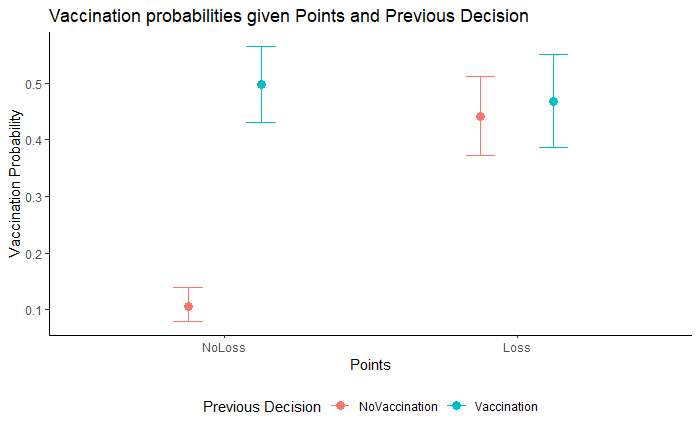

```r
# Your existing code for generating the plot
plot_data <- ggpredict(feedbackImpact, c("points", "decision_prev"), alpha = 0.05)

# Create the plot with error bar caps and dodge positioning
ggplot(plot_data, aes(x = factor(x, levels = unique(x)), y = predicted, ymin = conf.low, ymax = conf.high, color = as.factor(group))) +
  geom_point(position = position_dodge(width = 0.5), size = 3) +
  geom_errorbar(
    aes(ymin = conf.low, ymax = conf.high),
    position = position_dodge(width = 0.5),
    width = 0.2  # Adjust the width of the error bars
  ) +
  ggtitle("Vaccination probabilities given Points and Previous Decision") +
  ylab("Vaccination Probability") +
  scale_y_continuous(labels = function(x) format(x, scientific = FALSE)) +
  xlab("Points") +
  labs(color="Previous Decision") +
  #scale_color_manual(values=c("red", "blue")) +
  theme(legend.position = "bottom",
    panel.grid.major = element_blank(),
    panel.grid.minor = element_blank(),
    panel.background = element_blank(),
    axis.line = element_line(),
    axis.ticks = element_line() #colour = "grey"
  )
```

As we can see from the plot it is very clear that the interaction is mostly significant when there was no point loss: if the player did vaccinate in the previous wave the probability of vaccinating again is pretty high, while for if he did not vaccinate the probability is very low (and also with a very small variability). When there was point loss, instead, there is no substantial difference depending on the previous decision.

## 2.2 Behaviour Given Environmental Feedback

Here we will look at the impact of the feedback given to players at the end of the rounds (on the number of vaccinated, infected, recovered individuals).

We will take the model from Section 2.1 and add the **EOW Feedback** (end-of-wave feedback). These feedback will also have an interaction with **feedback_setting**, so to control for the *Global* and *Local* feedback conditions. We also need to exclude wave 5, as there was no EOW feedback coming from wave 4.

This model is reported in the original paper in **TABLE 2** and commented in **Section 2.2.**

```r
# Create train for EOW feedback
train612_readyc <- train512_readyc[train512_readyc['wave_no']>5,]

completeModel <- glmer(decision~(1|user)+points+decision_prev+points:decision_prev+wave_no_en+feedback_setting+vaccinated_eow+
                         infected_eow+susceptible_eow+vaccinated_eow:feedback_setting+infected_eow:feedback_setting+susceptible_eow:feedback_setting,
                       data=train612_readyc, family=binomial(link="logit"),control=glmerControl(optimizer="bobyqa",optCtrl=list(maxfun=2e5)))
summary(completeModel)
```

```
Generalized linear mixed model fit by maximum likelihood (Laplace Approximation) ['glmerMod']
 Family: binomial  ( logit )
Formula: decision ~ (1 | user) + points + decision_prev + points:decision_prev +      wave_no_en + feedback_setting + vaccinated_eow + infected_eow +
    susceptible_eow + vaccinated_eow:feedback_setting + infected_eow:feedback_setting +      susceptible_eow:feedback_setting
   Data: train612_readyc
Control: glmerControl(optimizer = "bobyqa", optCtrl = list(maxfun = 2e+05))

     AIC      BIC   logLik deviance df.resid
  1859.7   1935.3   -916.8   1833.7     2468

Scaled residuals:
    Min      1Q  Median      3Q     Max
-2.4679 -0.2299 -0.1647  0.3289  5.2814

Random effects:
 Groups Name        Variance Std.Dev.
 user   (Intercept) 3.227    1.797
Number of obs: 2481, groups:  user, 427

Fixed effects:
                                       Estimate Std. Error z value Pr(>|z|)
(Intercept)                            -2.34506    0.54257  -4.322 1.55e-05 ***
pointsLoss                              1.95753    0.24867   7.872 3.49e-15 ***
decision_prevVaccination                2.60201    0.30063   8.655  < 2e-16 ***
wave_no_en                             -0.24049    0.10101  -2.381   0.0173 *
feedback_settingGlobal                 -0.02245    0.73394  -0.031   0.9756
vaccinated_eow                         -0.08177    0.63066  -0.130   0.8968
infected_eow                            1.02777    2.56864   0.400   0.6891
susceptible_eow                         0.62957    0.48246   1.305   0.1919
pointsLoss:decision_prevVaccination    -2.04614    0.34189  -5.985 2.17e-09 ***
feedback_settingGlobal:vaccinated_eow  -0.27730    1.10294  -0.251   0.8015
feedback_settingGlobal:infected_eow    -0.62871    2.87324  -0.219   0.8268
feedback_settingGlobal:susceptible_eow -0.31248    0.82075  -0.381   0.7034
---
Signif. codes:  0 ‘***’ 0.001 ‘**’ 0.01 ‘*’ 0.05 ‘.’ 0.1 ‘ ’ 1

Correlation of Fixed Effects:
                   (Intr) pntsLs dcsn_V wv_n_n fdbc_G vccnt_ infct_ sscpt_ pnL:_V fdbck_sttngGlbl:v_ fdbck_sttngGlbl:n_
pointsLoss         -0.068
dcsn_prvVcc        -0.166  0.306
wave_no_en         -0.654 -0.172  0.115
fdbck_sttnG        -0.532 -0.009  0.099  0.354
vaccinatd_w        -0.610 -0.014  0.039  0.233  0.341
infected_ew        -0.151 -0.155 -0.007 -0.181  0.108  0.179
susceptbl_w        -0.697  0.070 -0.011  0.143  0.393  0.320  0.260
pntsLss:d_V         0.074 -0.732 -0.397  0.113 -0.025  0.016  0.105 -0.077
fdbck_sttngGlbl:v_  0.331  0.014 -0.051 -0.172 -0.647 -0.477 -0.069 -0.147  0.000
fdbck_sttngGlbl:n_  0.395  0.107 -0.040 -0.231 -0.405 -0.238 -0.793 -0.280 -0.070  0.172
fdbck_sttngGlbl:s_  0.363  0.006 -0.021 -0.131 -0.835 -0.144 -0.113 -0.486  0.017  0.255              0.262
```

```r
print(tidy(completeModel,conf.int=TRUE,exponentiate=TRUE,effects="fixed"))
```

| effect | term | estimate | std.error | statistic | p.value | conf.low | conf.high |
| --- | --- | --- | --- | --- | --- | --- | --- |
| fixed | (Intercept) | 0.09584153 | 0.05200032 | -4.3221665 | 1.545046e-05 | 0.03309184 | 0.2775789 |
| fixed | pointsLoss | 7.08183204 | 1.76102936 | 7.8720535 | 3.488669e-15 | 4.34989240 | 11.5295599 |
| fixed | decision_prevVaccination | 13.49086908 | 4.05580711 | 8.6551005 | 4.924777e-18 | 7.48411124 | 24.3186589 |
| fixed | wave_no_en | 0.78624242 | 0.07941847 | -2.3808507 | 1.727271e-02 | 0.64502489 | 0.9583772 |
| fixed | feedback_settingGlobal | 0.97779534 | 0.71764781 | -0.0305948 | 9.755927e-01 | 0.23201337 | 4.1208130 |
| fixed | vaccinated_eow | 0.92148632 | 0.58114432 | -0.1296537 | 8.968404e-01 | 0.26771355 | 3.1718120 |
| fixed | infected_eow | 2.79482044 | 7.17889078 | 0.4001212 | 6.890672e-01 | 0.01819377 | 429.3240522 |
| fixed | susceptible_eow | 1.87681185 | 0.90548130 | 1.3049335 | 1.919155e-01 | 0.72904186 | 4.8315781 |
| fixed | pointsLoss:decision_prevVaccination | 0.12923288 | 0.04418307 | -5.9848366 | 2.166072e-09 | 0.06612384 | 0.2525736 |
| fixed | feedback_settingGlobal:vaccinated_eow | 0.75782586 | 0.83583554 | -0.2514207 | 8.014889e-01 | 0.08724614 | 6.5825267 |

[output cut: 2 more lines]

We see again the impact of the interaction between previous decision, while the environmental feedback did not have a significant impact.

# 3 Survival Analysis

In this section we want to investigate the **daily feedback**. The best way to do so is through survival analysis: it allows to model scenarios in which there is an event that can happen or not to the subjects (usually death, that’s why survival) and thus uses the effects to model how many survive. In this scenario we will set *Vaccination* as the decision corresponding to the event of the models. They also take into account time and for this, since we look at the daily feedback, we’ll use the days within waves.

## 3.1 Behaviour Given Daily Feedback

```r
# Data from day 2
train512_readyc_noday1 <- train512_readyc[train512_readyc['day']>1,]

# Encode feedback setting with only 2 values
train512_readyc_noday1$feedback_setting <- factor(train512_readyc_noday1$feedback_setting, levels=c("Local", "Global"))
```

```r
train512_readyc_noday1
```

|  | user | wave_no | day | vaccinated_surv | infected_surv | recovered_surv | susceptible_surv | points | state | decision_prev | decision | feedback_setting | vaccinated_eow | infected_eow | recovered_eow | susceptible_eow | wave_no_en |
| --- | --- | --- | --- | --- | --- | --- | --- | --- | --- | --- | --- | --- | --- | --- | --- | --- | --- |
| 1 | 0 | 7 | 7 | 0.000000000 | 0.000000000 | 0.000000000 | 0.000000000 | NoLoss | 2 | NoVaccination | 0 | Local | 0.750000000 | 0.0000000000 | 0.0000000000 | 0.25000000 | 3 |
| 2 | 0 | 8 | 7 | 1.000000000 | 0.000000000 | 0.000000000 | 0.000000000 | NoLoss | 2 | NoVaccination | 0 | Local | 0.000000000 | 0.0000000000 | 0.0000000000 | 0.00000000 | 4 |
| 3 | 0 | 9 | 7 | 0.230769231 | 0.000000000 | 0.028340081 | 0.740890688 | NoLoss | 2 | NoVaccination | 0 | Global | 0.850000000 | 0.0000000000 | 0.0000000000 | 0.15000000 | 1 |
| 4 | 1 | 11 | 2 | 0.166666667 | 0.032520325 | 0.000000000 | 0.800813008 | NoLoss | 2 | NoVaccination | 1 | Global | 0.269754768 | 0.1880108992 | 0.1880108992 | 0.54223433 | 3 |
| 5 | 1 | 12 | 7 | 0.200404858 | 0.000000000 | 0.103238866 | 0.696356275 | Loss | 1 | Vaccination | 0 | Global | 0.291891892 | 0.1216216216 | 0.1216216216 | 0.58648649 | 4 |
| 6 | 1 | 5 | 7 | 0.000000000 | 0.000000000 | 0.000000000 | 1.000000000 | Loss | 0 | NoVaccination | 0 | Local | 0.282017971 | 0.0546756023 | 0.0756785717 | 0.57068414 | 1 |
| 7 | 1 | 6 | 7 | 0.416666667 | 0.000000000 | 0.000000000 | 0.583333333 | NoLoss | 2 | NoVaccination | 0 | Local | 0.197651663 | 0.0000000000 | 0.0019569472 | 0.80039139 | 2 |
| 8 | 1 | 7 | 7 | 0.000000000 | 0.000000000 | 0.000000000 | 0.000000000 | NoLoss | 2 | NoVaccination | 0 | Local | 0.465517241 | 0.0000000000 | 0.0000000000 | 0.53448276 | 3 |
| 9 | 1 | 8 | 7 | 0.000000000 | 0.000000000 | 0.000000000 | 0.000000000 | NoLoss | 2 | NoVaccination | 0 | Local | 0.000000000 | 0.0000000000 | 0.0093457944 | 0.99065421 | 4 |
| 10 | 10 | 10 | 7 | 0.199186992 | 0.006097561 | 0.130081301 | 0.664634146 | NoLoss | 2 | NoVaccination | 0 | Global | 0.306451613 | 0.0376344086 | 0.0376344086 | 0.65591398 | 2 |

[output cut: 990 more lines]

```r
# Go back to percentages. Does not change the model, but easier plots

for(i in rownames(train512_readyc_noday1)) {
  train512_readyc_noday1[i, 4] <- train512_readyc_noday1[i, 4]*100
  train512_readyc_noday1[i, 5] <- train512_readyc_noday1[i, 5]*100
  train512_readyc_noday1[i, 6] <- train512_readyc_noday1[i, 6]*100
  train512_readyc_noday1[i, 7] <- train512_readyc_noday1[i, 7]*100
}
```

We can also use `coxph` which is just a different implementation, but it is easier to use to plot the data. The data reported in the paper in TABLE 3 is actually the `coxph` model.

```r
cox_feedback <- coxme(Surv(day, decision) ~ (1|user)+points+decision_prev+points:decision_prev+feedback_setting+vaccinated_surv+wave_no_en+
                        infected_surv+susceptible_surv+feedback_setting:vaccinated_surv+feedback_setting:infected_surv+feedback_setting:susceptible_surv,
                      data=train512_readyc_noday1)
summary(cox_feedback)
```

```
Mixed effects coxme model
 Formula: Surv(day, decision) ~ (1 | user) + points + decision_prev + points:decision_prev +      feedback_setting + vaccinated_surv + wave_no_en + infected_surv +      susceptible_surv + feedback_setting:vaccinated_surv + feedback_setting:infected_surv +      feedback_setting:susceptible_surv
    Data: train512_readyc_noday1

  events, n = 121, 2003

Random effects:
```

| group | variable | sd | variance |
| --- | --- | --- | --- |
| user | Intercept | 0.7735647 | 0.5984024 |

```
                  Chisq    df p   AIC   BIC
Integrated loglik 306.3 12.00 0 282.3 248.8
 Penalized loglik 418.2 62.75 0 292.7 117.2

Fixed effects:
                                              coef  exp(coef)   se(coef)     z        p
pointsLoss                               4.573e-01  1.580e+00  3.251e-01  1.41 0.159530
decision_prevVaccination                 1.470e+00  4.348e+00  2.358e-01  6.23 4.57e-10
feedback_settingGlobal                  -1.867e+01  7.817e-09  4.890e+00 -3.82 0.000135
vaccinated_surv                          1.253e-03  1.001e+00  5.171e-03  0.24 0.808574
wave_no_en                              -7.476e-02  9.280e-01  9.494e-02 -0.79 0.431028
infected_surv                            1.239e-02  1.012e+00  2.467e-02  0.50 0.615330
susceptible_surv                         1.648e-02  1.017e+00  3.065e-03  5.38 7.57e-08
pointsLoss:decision_prevVaccination     -3.569e-01  6.998e-01  4.556e-01 -0.78 0.433341
feedback_settingGlobal:vaccinated_surv  -6.187e-02  9.400e-01  1.171e-01 -0.53 0.597293
feedback_settingGlobal:infected_surv     4.352e-01  1.545e+00  2.339e-01  1.86 0.062838
feedback_settingGlobal:susceptible_surv  2.611e-01  1.298e+00  5.934e-02  4.40 1.08e-05
```

```r
confint(cox_feedback, level = 0.95)
```

```
                                                2.5 %      97.5 %
pointsLoss                               -0.179876369  1.09445883
decision_prevVaccination                  1.007556303  1.93183021
feedback_settingGlobal                  -28.252116272 -9.08184134
vaccinated_surv                          -0.008881621  0.01138696
wave_no_en                               -0.260846634  0.11132378
infected_surv                            -0.035949124  0.06073663
susceptible_surv                          0.010472532  0.02248560
pointsLoss:decision_prevVaccination      -1.249869933  0.53598299
feedback_settingGlobal:vaccinated_surv   -0.291392966  0.16765841
feedback_settingGlobal:infected_surv     -0.023305527  0.89363423
feedback_settingGlobal:susceptible_surv   0.144837470  0.37744347
```

```r
cox_feedback_asd <- coxph(Surv(day, decision) ~ frailty(user)+points+decision_prev+points:decision_prev+feedback_setting+vaccinated_surv+wave_no_en+
                        infected_surv+susceptible_surv+feedback_setting:vaccinated_surv+feedback_setting:infected_surv+feedback_setting:susceptible_surv,
                      data=train512_readyc_noday1)
summary(cox_feedback_asd)
```

```
Call:
coxph(formula = Surv(day, decision) ~ frailty(user) + points +
    decision_prev + points:decision_prev + feedback_setting +
    vaccinated_surv + wave_no_en + infected_surv + susceptible_surv +
    feedback_setting:vaccinated_surv + feedback_setting:infected_surv +
    feedback_setting:susceptible_surv, data = train512_readyc_noday1)

  n= 2003, number of events= 121

                          coef      se(coef) se2      Chisq DF    p
frailty(user)                                         89.61 71.54 7.3e-02
pointsLoss                  0.46520 0.329334 0.317775  2.00  1.00 1.6e-01
decision_prevVaccination    1.45143 0.239374 0.224533 36.77  1.00 1.3e-09
feedback_settingGlobal    -18.66732 4.907544 4.814594 14.47  1.00 1.4e-04
vaccinated_surv             0.00132 0.005229 0.005077  0.06  1.00 8.0e-01
wave_no_en                 -0.08117 0.095653 0.092804  0.72  1.00 4.0e-01
infected_surv               0.01319 0.025200 0.023960  0.27  1.00 6.0e-01
susceptible_surv            0.01673 0.003099 0.002966 29.13  1.00 6.8e-08
pointsLoss:decision_prevV  -0.32196 0.462519 0.437571  0.48  1.00 4.9e-01
feedback_settingGlobal:va  -0.06738 0.118438 0.111660  0.32  1.00 5.7e-01
feedback_settingGlobal:in   0.44249 0.235424 0.221721  3.53  1.00 6.0e-02
feedback_settingGlobal:su   0.26245 0.059470 0.057817 19.48  1.00 1.0e-05

                          exp(coef) exp(-coef) lower .95 upper .95
pointsLoss                1.592e+00  6.280e-01 8.350e-01 3.0364428
decision_prevVaccination  4.269e+00  2.342e-01 2.670e+00 6.8250181
feedback_settingGlobal    7.814e-09  1.280e+08 5.195e-13 0.0001175
vaccinated_surv           1.001e+00  9.987e-01 9.911e-01 1.0116353
wave_no_en                9.220e-01  1.085e+00 7.644e-01 1.1121609
infected_surv             1.013e+00  9.869e-01 9.644e-01 1.0645756
susceptible_surv          1.017e+00  9.834e-01 1.011e+00 1.0230634
pointsLoss:decision_prevV 7.247e-01  1.380e+00 2.927e-01 1.7942019
feedback_settingGlobal:va 9.348e-01  1.070e+00 7.412e-01 1.1791026
feedback_settingGlobal:in 1.557e+00  6.424e-01 9.812e-01 2.4692546
feedback_settingGlobal:su 1.300e+00  7.692e-01 1.157e+00 1.4608341

Iterations: 6 outer, 31 Newton-Raphson
     Variance of random effect= 0.8648392   I-likelihood = -758.1
Degrees of freedom for terms= 71.5  0.9  0.9  1.0  0.9  0.9  0.9  0.9  0.9  0.9  0.9  0.9
Concordance= 0.937  (se = 0.01 )
Likelihood ratio test= 430  on 81.63 df,   p=<2e-16
```

Now let’s get the confidence intervals for the model.

```r
# Confidence Intervals
confint(cox_feedback_asd)
```

```
                                                2.5 %      97.5 %
pointsLoss                               -0.180280638  1.11068669
decision_prevVaccination                  0.982264887  1.92059499
feedback_settingGlobal                  -28.285931379 -9.04871099
vaccinated_surv                          -0.008927429  0.01156810
wave_no_en                               -0.268647109  0.10630486
infected_surv                            -0.036205324  0.06257618
susceptible_surv                          0.010652173  0.02280148
pointsLoss:decision_prevVaccination      -1.228482713  0.58456029
feedback_settingGlobal:vaccinated_surv   -0.299515085  0.16475364
feedback_settingGlobal:infected_surv     -0.018928924  0.90391632
feedback_settingGlobal:susceptible_surv   0.145889101  0.37900758
```

Next we want to display the overall outcome of the model. We can show it with the survival curve, also by dividing the two different feedback conditions, i.e., local feedback and global feedback. We see that if we don’t consider day 1, in which most of the vaccinations happen, the unvaccinated remain the majority and there is no day with a way bigger amount of vaccinations than another, and no significant difference between the conditions.

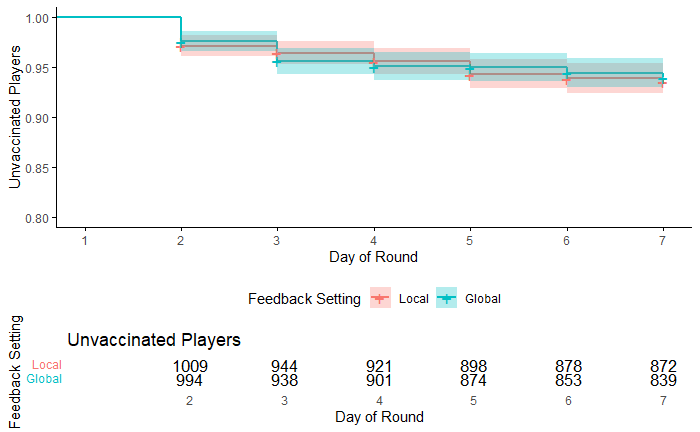

```r
# Create the survival curve object, stratifying by feedback_setting directly
surv_fit <- survfit(Surv(day, decision) ~ feedback_setting, data = train512_readyc_noday1)

# Plot the survival curves
plt <- ggsurvplot(
  surv_fit,
  data = train512_readyc_noday1,
  xlab = "Day of Round",
  ylab = "Unvaccinated Players",
  ggtheme = theme_minimal() +
    theme(panel.grid.major = element_blank(),
          panel.grid.minor = element_blank()),
  risk.table = TRUE,          # Add a risk table
  risk.table.title = "Unvaccinated Players", # Change table title
  conf.int = TRUE,            # Add confidence intervals
  ylim = c(0.8, 1.0),         # Limits for readability
  xlim = c(1,7),              # Limits for readability
  legend.title = "Feedback Setting",
  legend.labs = levels(train512_readyc_noday1$feedback_setting)
)

# Add main axes only in the plot
plt$plot <- plt$plot +
  scale_x_continuous(breaks = seq(0, 7, by = 1)) +
  theme(legend.position = "bottom",axis.line = element_line())
# Extract the plot and the risk table
surv_plot <- plt$plot
risk_table <- plt$table

# Combine the plot and the risk table using cowplot
combined_plot <- plot_grid(
  surv_plot, risk_table,
  ncol = 1,
  rel_heights = c(3, 1)  # Adjust the relative heights as needed
)

print(combined_plot)
```

Finally, let’s plot the most interesting interaction, meaning the one between the feedback setting and the susceptible daily feedback. This is FIGURE 2 of the paper. The figure below also puts the ribbon for the 95% CI, but it hinders the readability of the plot.

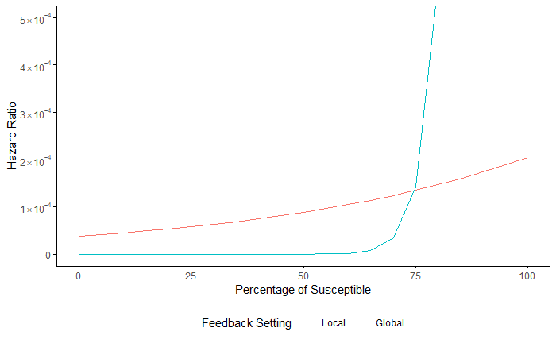

```r
data_plt_inf <- ggpredict(cox_feedback_asd, c("susceptible_surv", "feedback_setting"))

# Function for the y axis formatting
scientific_10 = function(x) {
  ifelse(
    x==0, "0",
    parse(text = sub("e[+]?", " %*% 10^", scales::scientific_format()(x)))
  )
}

# Create the plot
ggplot(data_plt_inf, aes(x = x, y = predicted)) +
  geom_line(aes(color = group)) +
  ylab("Hazard Ratio") +
  xlab("Percentage of Susceptible") +
  scale_y_continuous(labels = scientific_10) +
  #scale_y_continuous(limits = c(0, 0.0005)) +# if you want to cut the plot
  #scale_y_log10() + # If you want the plot in logscale
  scale_color_discrete(name = "Feedback Setting") +
  theme_minimal() +  # Use a minimal theme
  theme(legend.position = "bottom",  # Move the legend to the bottom
        panel.grid.major = element_blank(),
        panel.grid.minor = element_blank(),
        panel.background = element_blank(),
        axis.line = element_line(),
        axis.ticks = element_line())+
  coord_cartesian(ylim = c(min(data_plt_inf$predicted), max(0.0005)))  # Set y-axis limit without removing data points
```

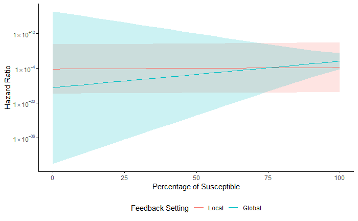

```r
# Change again (logscale and doesn't need 0)
scientific_10 <- function(x) {
  parse(text = gsub("e", " %*% 10^", scales::scientific_format()(x)))
}

# Create the plot
ggplot(data_plt_inf, aes(x = x, y = predicted)) +
  geom_ribbon(aes(ymin = conf.low, ymax = conf.high, fill = group), alpha = 0.2, show.legend = FALSE) +
  geom_line(aes(color = group)) +
  ylab("Hazard Ratio") +
  xlab("Percentage of Susceptible") +
  scale_y_log10(labels = scientific_10) +
  scale_color_discrete(name = "Feedback Setting") +
  theme_minimal() +  # Use a minimal theme
  theme(legend.position = "bottom",  # Move the legend to the bottom
        panel.grid.major = element_blank(),
        panel.grid.minor = element_blank(),
        panel.background = element_blank(),
        axis.line = element_line(),
        axis.ticks = element_line())
```